# ANALYZE_casestudy_01_cyclisticbikeshare_2019to2020

### Analyze the start_day and end_day of the casual users (again without the suspicious station names)

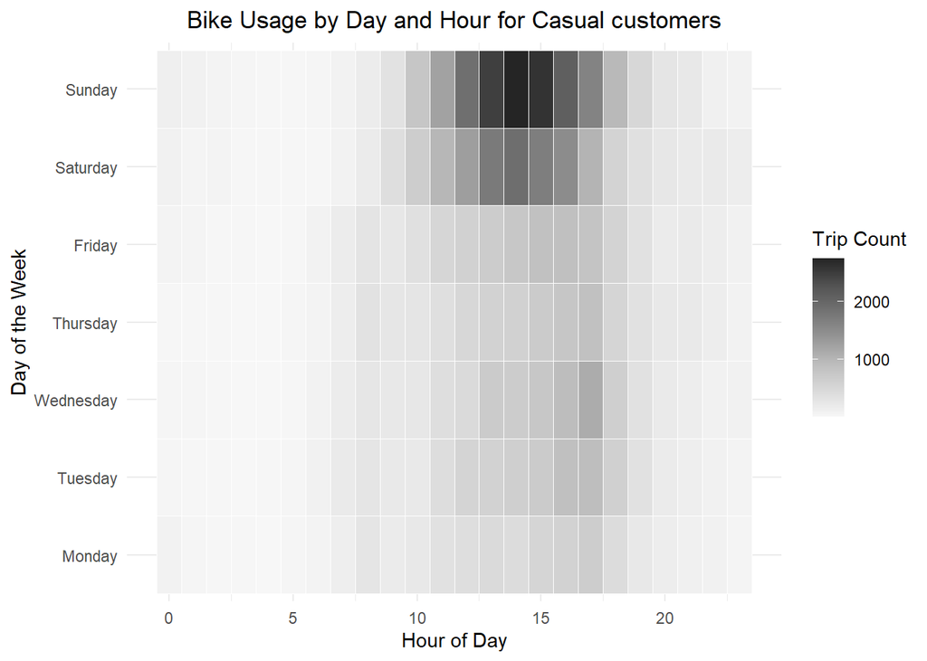

```r
# Analyze hour-start day combination
cal_time_hour_startday_casual <- data_chart_combined_casual %>%
  mutate(
    day = wday(start_time, label = TRUE, abbr = FALSE),
    hour = hour(start_time)
  ) %>%
  group_by(day, hour) %>%
  summarise(trip_count = n(), .groups = "drop") %>%
  arrange(desc(trip_count))

cal_time_hour_startday_casual <-  cal_time_hour_startday_casual %>%
  mutate(day = factor(day, levels = c("Monday", "Tuesday", "Wednesday", "Thursday", "Friday", "Saturday", "Sunday")))

ggplot(cal_time_hour_startday_casual, aes(x = hour, y = day, fill = trip_count)) +
  geom_tile(color = "white") +
  scale_fill_distiller(palette = "Greys", direction = 1) +
  labs(title = "Bike Usage by Day and Hour for Casual customers",
       x = "Hour of Day",
       y = "Day of the Week",
       fill = "Trip Count") +
  theme_minimal() +
  theme(
    plot.title = element_text(hjust = 0.5)
  )
```

```r
# Visualizing hour-start day combination
cal_time_hour_startday_casual
```

```
## # A tibble: 168 × 3
##    day       hour trip_count
##    <ord>    <int>      <int>
##  1 Sunday      14       2750
##  2 Sunday      15       2597
##  3 Sunday      13       2477
##  4 Sunday      16       2104
##  5 Saturday    14       1897
##  6 Sunday      12       1885
##  7 Saturday    13       1737
##  8 Saturday    15       1687
##  9 Sunday      17       1628
## 10 Saturday    16       1503
## # ℹ 158 more rows
```

### Analyze the start_day and end_day of the Member users

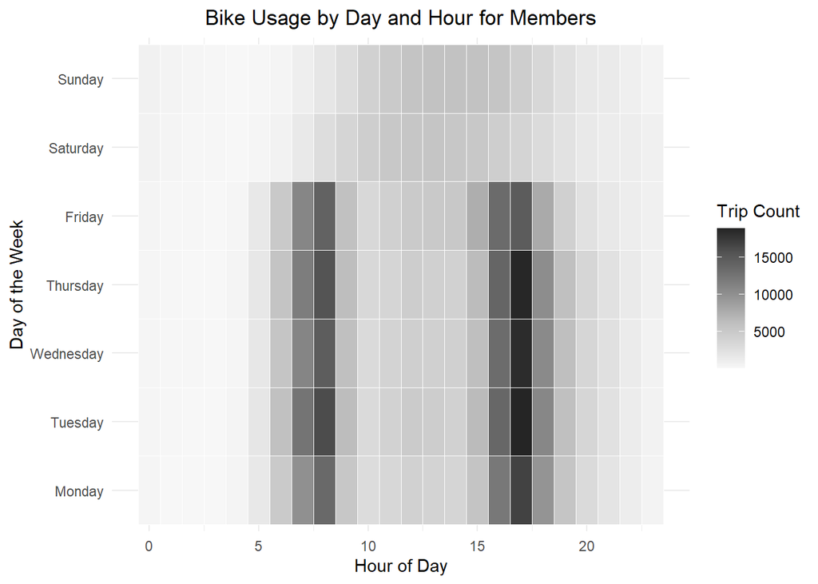

```r
# Analyze hour-start day combination
cal_time_hour_startday_member <- data_chart_combined_member %>%
  mutate(
    day = wday(start_time, label = TRUE, abbr = FALSE),
    hour = hour(start_time)
  ) %>%
  group_by(day, hour) %>%
  summarise(trip_count = n(), .groups = "drop") %>%
  arrange(desc(trip_count))

cal_time_hour_startday_member <-  cal_time_hour_startday_member %>%
  mutate(day = factor(day, levels = c("Monday", "Tuesday", "Wednesday", "Thursday", "Friday", "Saturday", "Sunday")))

ggplot(cal_time_hour_startday_member, aes(x = hour, y = day, fill = trip_count)) +
  geom_tile(color = "white") +
  scale_fill_distiller(palette = "Greys", direction = 1) +
  labs(title = "Bike Usage by Day and Hour for Members",
       x = "Hour of Day",
       y = "Day of the Week",
       fill = "Trip Count") +
  theme_minimal() +
  theme(
    plot.title = element_text(hjust = 0.5)
  )
```

```r
# Visualizing hour-start day combination
cal_time_hour_startday_member
```

```
## # A tibble: 168 × 3
##    day        hour trip_count
##    <ord>     <int>      <int>
##  1 Tuesday      17      18890
##  2 Thursday     17      18715
##  3 Wednesday    17      18376
##  4 Monday       17      16809
##  5 Tuesday       8      16166
##  6 Thursday      8      15536
##  7 Friday       17      14782
##  8 Wednesday     8      14657
##  9 Friday        8      14189
## 10 Thursday     16      13931
## # ℹ 158 more rows
```

### Compare popular starting and station for the Casual users vs. that for the Member users

```r
# Explore popular starting station for the Casual usertype
cal_loc_popstart_casual <- data_chart_combined_casual %>%
  group_by(from_station_id, from_station_name) %>%
  summarise(trip_count = n(), .groups = "drop") %>%
  arrange(desc(trip_count)) %>%
  slice_head(n = 10)

cal_loc_popstart_casual
```

```
## # A tibble: 10 × 3
##    from_station_id from_station_name            trip_count
##    <chr>           <chr>                             <int>
##  1 35              Streeter Dr & Grand Ave            2749
##  2 76              Lake Shore Dr & Monroe St          2732
##  3 3               Shedd Aquarium                     1832
##  4 90              Millennium Park                    1406
##  5 85              Michigan Ave & Oak St              1017
##  6 43              Michigan Ave & Washington St        839
##  7 6               Dusable Harbor                      832
##  8 341             Adler Planetarium                   826
##  9 177             Theater on the Lake                 795
## 10 268             Lake Shore Dr & North Blvd          606
```

```r
# Compare the popular starting station for the Member usertype
cal_loc_popstart_member <- data_chart_combined_member %>%
  group_by(from_station_id, from_station_name) %>%
  summarise(trip_count = n(), .groups = "drop") %>%
  arrange(desc(trip_count)) %>%
  slice_head(n = 10)

cal_loc_popstart_member
```

```
## # A tibble: 10 × 3
##    from_station_id from_station_name            trip_count
##    <chr>           <chr>                             <int>
##  1 192             Canal St & Adams St               13799
##  2 91              Clinton St & Washington Blvd      13434
##  3 77              Clinton St & Madison St           12891
##  4 133             Kingsbury St & Kinzie St           8720
##  5 195             Columbus Dr & Randolph St          8515
##  6 174             Canal St & Madison St              7957
##  7 287             Franklin St & Monroe St            7010
##  8 43              Michigan Ave & Washington St       6686
##  9 48              Larrabee St & Kingsbury St         6467
## 10 66              Clinton St & Lake St               6439
```

```r
# Explore popular ending station for the Casual usertype
cal_loc_popend_casual <- data_chart_combined_casual %>%
  group_by(to_station_id, to_station_name) %>%
  summarise(trip_count = n(), .groups = "drop") %>%
  arrange(desc(trip_count)) %>%
  slice_head(n = 10)

cal_loc_popend_casual
```

```
## # A tibble: 10 × 3
##    to_station_id to_station_name              trip_count
##    <chr>         <chr>                             <int>
##  1 35            Streeter Dr & Grand Ave            3790
##  2 76            Lake Shore Dr & Monroe St          2160
##  3 90            Millennium Park                    1934
##  4 3             Shedd Aquarium                     1461
##  5 85            Michigan Ave & Oak St              1185
##  6 177           Theater on the Lake                1080
##  7 43            Michigan Ave & Washington St        965
##  8 268           Lake Shore Dr & North Blvd          771
##  9 199           Wabash Ave & Grand Ave              745
## 10 341           Adler Planetarium                   712
```

```r
# Compare the popular ending station for the Member usertype
cal_loc_popend_member <- data_chart_combined_member %>%
  group_by(to_station_id, to_station_name) %>%
  summarise(trip_count = n(), .groups = "drop") %>%
  arrange(desc(trip_count)) %>%
  slice_head(n = 10)

cal_loc_popend_member
```

```
## # A tibble: 10 × 3
##    to_station_id to_station_name              trip_count
##    <chr>         <chr>                             <int>
##  1 192           Canal St & Adams St               14807
##  2 91            Clinton St & Washington Blvd      14580
##  3 77            Clinton St & Madison St           13310
##  4 133           Kingsbury St & Kinzie St           8798
##  5 174           Canal St & Madison St              8265
##  6 43            Michigan Ave & Washington St       7674
##  7 66            Clinton St & Lake St               6709
##  8 287           Franklin St & Monroe St            6315
##  9 81            Daley Center Plaza                 6300
## 10 283           LaSalle St & Jackson Blvd          6238
```

- Popular locations for the Casual usertype based on the from_station_name can all be considered to be sight seeing locations.
- Considering that the urge to use the service is maximized before the service is used, it would be wise to have advertisements located near from_station_name.
- Also, it would be wise to have a weekend plan membership, which would convert many of the casual picnic lovers into membership as well.